# Health System Dispensing Analysis

This is the analysis of *HealthSystem A* provided Pharmacy Dispensing Data for:

1. **Hospital Pharmacies (4) | 75850 Records | Jan 1 2019 to July 30 2019**
2. **Remote Mail Order (1) | 253833 Records | June 28, 2018 to June 27 2019**

A third Dataset is used for mapping NDC’s provided in these dispensing files to Industry Standard 11 Digit NDC numbers to identify specific medications

3. **NDC Map | 1814 Records**

### Analysis of combined Dispensing data

Within the combined Dataset, there were **329683** observed Prescription dispensing events. Totaling **$96,904,208**. Of the total revenue, **$39,332,536** represents Specialty Medications and **$57,571,672** represents Non-Specialty.  
Other summary stats:  
* Unique ordering Physicians **12847**  
* Unique dispensed NDC’s **6411**  
* Average dispensed volume daily (Hospital Pharmacies) **363**  
* Average dispensed volume daily (Mail Order) **891**

#### Top Drugs Prescribed by Quantity Dispensed

| Drug Name | Quantity Dispensed | Total Revenue |
| --- | --- | --- |
| AMLODIPINE BESYLATE 5 MG TAB | 2963 | 29650 |
| ATORVASTATIN 20 MG TABLET | 2968 | 32672.65 |
| ATORVASTATIN 40 MG TABLET | 2618 | 33319.6 |
| FLUTICASONE PROP 50 MCG SPRAY | 2479 | 25504.72 |
| LOSARTAN POTASSIUM 50 MG TAB | 2564 | 25656.8 |
| METFORMIN HCL ER 500 MG TABLET | 2398 | 28256.16 |
| MONTELUKAST SOD 10 MG TABLET | 3453 | 34550 |
| PANTOPRAZOLE SOD DR 40 MG TAB | 3792 | 39866.05 |
| TACROLIMUS 1MG CAP | 2970 | 325658.63 |
| TRUE METRIX GLUCOSE TEST STRIP | 2443 | 273360 |

> Across the Health System’s combined Pharmacy business lines, the top **quantity** Medications dispensed are primarily traditional non-specialy medications that are common high-turn inventory at typical Retail and Mail Order locations. With the exception of the Immunosuppressive *TACROLIMUS*, the majority are maintenace mediations for typical health conditions (i.e. High blood pressure, Asthma, High cholestrol and Diabetes). This is a contrast from evaluating the same data for the top Mediations dispensed by Revenue as shown below:

#### Top Drugs Prescribed by Revenue

| Drug Name | Dispensed | Total Revenue |
| --- | --- | --- |
| COSENTYX 300 MG DOSE-2 PENS | 80 | 1148807.02 |
| ENBREL 50 MG/ML SURECLICK SYR | 151 | 1844487.74 |
| GENVOYA TABLET | 147 | 1195614.72 |
| HUMIRA PEN 40 MG/0.8 ML | 291 | 4208035.96 |
| HUMIRA(CF) PEN 40 MG/0.4 ML | 167 | 2114434.18 |
| JAKAFI 5MG TAB | 84 | 1299512.33 |
| OMNITROPE 10 MG/1.5 ML CRTG | 155 | 2778692.54 |
| STELARA 90 MG/ML SYRINGE | 98 | 1988794.18 |
| TRULICITY 1.5 MG/0.5 ML PEN | 772 | 1579909.04 |
| VICTOZA 3-PAK 18 MG/3 ML PEN | 552 | 1332464.85 |

> As expected, the top Medications dispensed by Revenue are more heavily skewed toward Specialty Medications. A number of injectble inflammatory disease drugs and oral oncolytics dispensed at much lower volumes still represent significant costs and revenue for HealthSystem A. These drugs are generally are prescribed by Specialists seeking to monitor how their patients are doing on Therapy as well as ease and transparency in determining status of referrals. Higher cost medications raise the level of expecations for both patient and provider.

#### Revenue by Specialty

| Specialty | Avg Revenue per RX | Total Revenue |
| --- | --- | --- |
| Allergy &amp; Immunology | 4005.47247588424 | 1245701.94 |
| Cardiology | 2402.24186046512 | 413185.6 |
| Inflammatory Diseases | 12408.6365752286 | 14927589.8 |
| Endocrinology | 15350.2533478261 | 3530558.27 |
| Gastroenterology | 6528.95170818505 | 1834635.43 |
| Oncology &amp; Hem | 6348.92418835192 | 10247163.64 |
| Infectious Disease | 5442.55318014706 | 2960748.93 |
| Nephrology | 2500.15915254237 | 147509.39 |
| Neurology | 4241.85634285714 | 1484649.72 |
| Pulmonary | 5887.59807017544 | 335593.09 |

[output cut: 2 more lines]

#### Top Prescribers of Specialty Medications by Revenue

| Physician ID | Dispensed | Total Revenue |
| --- | --- | --- |
| 149441 | 59 | 663611.5 |
| 137780 | 120 | 1045919.63 |
| 147459 | 49 | 723013.81 |
| 147892 | 51 | 866656.71 |
| 138842 | 81 | 618971.65 |
| 145650 | 191 | 1556537.89 |
| 145320 | 66 | 579433.24 |
| 144682 | 67 | 991499.34 |
| 146109 | 59 | 776400.48 |
| 146430 | 90 | 1143771.93 |

#### Fill analysis

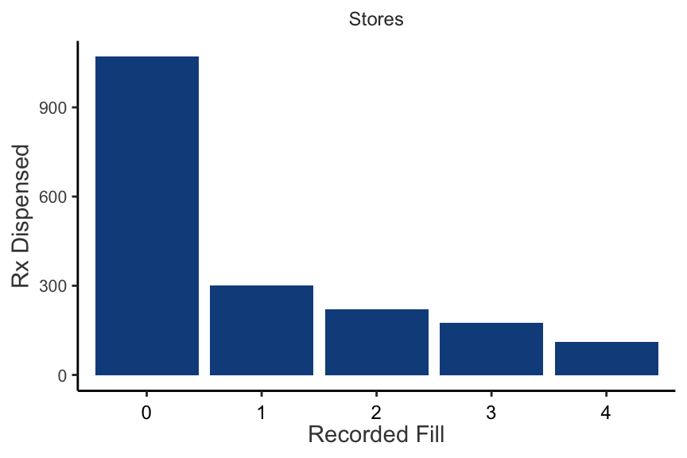

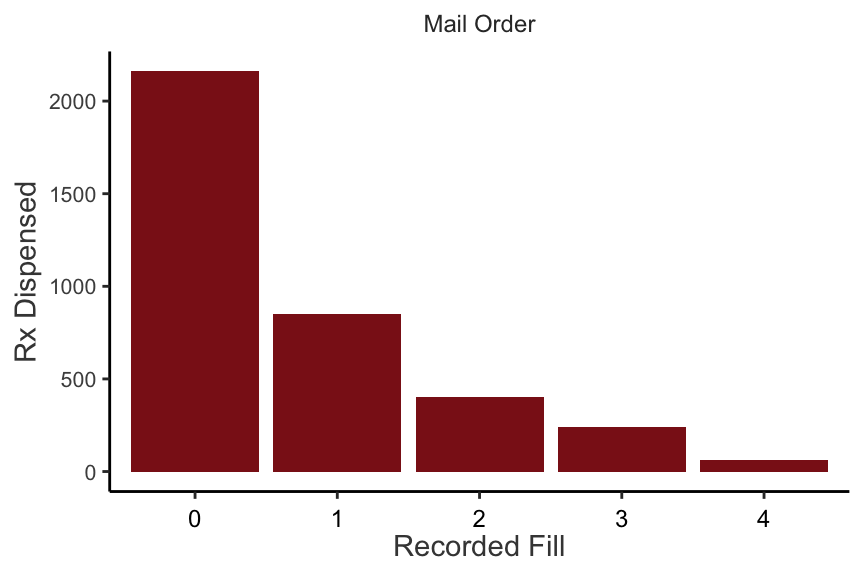

#### Revenue Quartiles by Specialty

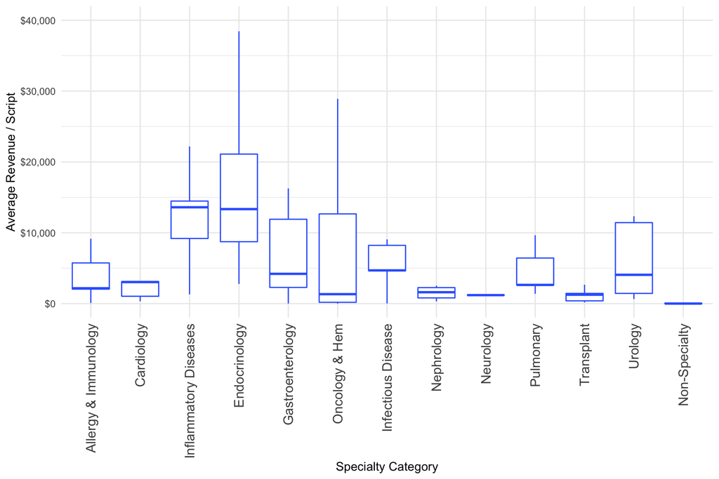

#### Dispensing by Month

##### Line is Quantity of Specialty Dispensing

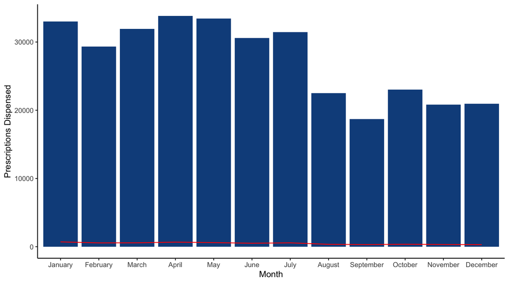

#### Location of Specialty Dispensing

| Pharmacy Location | # of Specialty Rx Dispensed | Specialty Revenue |
| --- | --- | --- |
| Riverside | 1154 | 7796682.61 |
| West | 636 | 1615425.89 |
| Central | 230 | 573061.38 |
| OCC | 1 | 53.61 |
| Mail Order | 3819 | 29347312.96 |

###### Back to Portfolio of Work